# Logistic regression

Anna Hutchinson

22/10/2018

#### Aim: Estimate coverage of credible sets (in fine mapping genetic associations).

##### Method: Use logistic regression to analyse the relationship between coverage and entropy, nvar, N, OR, nsnps, thr and size.

#### Read in data/ data prep:

```r
library(data.table)
setwd("/Users/anna/PhD")
cs <- read.table("cs for diff nsnps")
cs <- as.data.table(cs)
cs_ord <- cs[order=="TRUE"] # separate ordered and non-ordered simulations
cs_noord <- cs[order=="FALSE"]
cs_ord$covered <- as.numeric(cs_ord$covered) # has dim 200,000*9
cs_noord$covered <- as.numeric(cs_noord$covered) # has dim 200,000*9
cs_ord <- cs_ord[,-1] # remove order column
cs_noord <- cs_noord[,-1]
head(cs_ord)
```

```
##    thr      size nvar covered  entropy    N  OR nsnps
## 1: 0.6 0.6094180   10       1 5.306601 5000 1.1   100
## 2: 0.6 0.6069801   32       0 4.859282 5000 1.1   100
## 3: 0.6 0.6598043    1       1 5.843130 5000 1.1   100
## 4: 0.6 0.7162386    1       1 6.000415 5000 1.1   100
## 5: 0.6 0.6133004    4       0 5.491237 5000 1.1   100
## 6: 0.6 0.6057816   10       1 5.310640 5000 1.1   100
```

```r
head(cs_noord)
```

```
##    thr      size nvar covered  entropy    N  OR nsnps
## 1: 0.6 0.6231312   38       1 5.306601 5000 1.1   100
## 2: 0.6 0.6068766   54       0 4.859282 5000 1.1   100
## 3: 0.6 0.8186720   46       1 5.843130 5000 1.1   100
## 4: 0.6 0.7827822   14       1 6.000415 5000 1.1   100
## 5: 0.6 0.7888346   59       1 5.491237 5000 1.1   100
## 6: 0.6 0.6027625   49       0 5.310640 5000 1.1   100
```

The ‘cs’ dataset contains information for 400,000 credible set simulations with varying combinations of OR, threshold, N and nsnps values.

Sampled OR values: 1, 1.05, 1.1, 1.2, 1.3.

Sampled thr values:0.5,0.6,0.7,0.8,0.9.

Sampled N values: 1000, 2000, 3000, 4000, 5000.

Sampled nsnps values: 100, 300, 500, 1000.

#### Individual effect of each variable

Logistic models were fit with each variable as the sole predictor. Fake data was then created for each variable, and the corresponding logistic model used to predict coverage for the fake data.

```r
xent <- glm(covered~entropy, data=cs_ord, family='binomial')
xthr <- glm(covered~thr, data=cs_ord, family='binomial')
xsize <- glm(covered~size, data=cs_ord, family='binomial')
xnsnps <- glm(covered~nsnps, data=cs_ord, family='binomial')
xN <- glm(covered~N, data=cs_ord, family='binomial')
xnvar <- glm(covered~nvar, data=cs_ord, family='binomial')
xOR <- glm(covered~OR, data=cs_ord, family='binomial')

fake_ent <- data.frame(entropy=seq(4,40,by=0.1))
fake_ent$pred <- predict(xent,newdata=fake_ent,family=binomial,type="response")

fake_thr <- data.frame(thr=seq(0.5,1,by=0.01))
fake_thr$pred <- predict(xthr,newdata=fake_thr,family=binomial,type="response")

fake_size <- data.frame(size=seq(0.5,1,by=0.01))
fake_size$pred <- predict(xsize,newdata=fake_size,family=binomial,type="response")

fake_nsnps <- data.frame(nsnps=seq(100,1000,by=1))
fake_nsnps$pred <- predict(xnsnps,newdata=fake_nsnps,family=binomial,type="response")

fake_N <- data.frame(N=seq(1000,5000,by=1))
fake_N$pred <- predict(xN,newdata=fake_N,family=binomial,type="response")

fake_nvar <- data.frame(nvar=seq(1,843,by=1))
fake_nvar$pred <- predict(xnvar,newdata=fake_nvar,family=binomial,type="response")

fake_OR <- data.frame(OR=seq(1,1.5,by=0.01))
fake_OR$pred <- predict(xOR,newdata=fake_OR,family=binomial,type="response")
```

The same method was implemented for the non-ordered data for comparison

```r
yent <- glm(covered~entropy, data=cs_noord, family='binomial')
ythr <- glm(covered~thr, data=cs_noord, family='binomial')
ysize <- glm(covered~size, data=cs_noord, family='binomial')
ynsnps <- glm(covered~nsnps, data=cs_noord, family='binomial')
yN <- glm(covered~N, data=cs_noord, family='binomial')
ynvar <- glm(covered~nvar, data=cs_noord, family='binomial')
yOR <- glm(covered~OR, data=cs_noord, family='binomial')

fake_ent$pred1 <- predict(yent,newdata=fake_ent,family=binomial,type="response")
fake_thr$pred1 <- predict(ythr,newdata=fake_thr,family=binomial,type="response")
fake_size$pred1 <- predict(ysize,newdata=fake_size,family=binomial,type="response")
fake_nsnps$pred1 <- predict(ynsnps,newdata=fake_nsnps,family=binomial,type="response")
fake_N$pred1 <- predict(yN,newdata=fake_N,family=binomial,type="response")
fake_nvar$pred1 <- predict(ynvar,newdata=fake_nvar,family=binomial,type="response")
fake_OR$pred1 <- predict(yOR,newdata=fake_OR,family=binomial,type="response")
```

### Results

#### Entropy

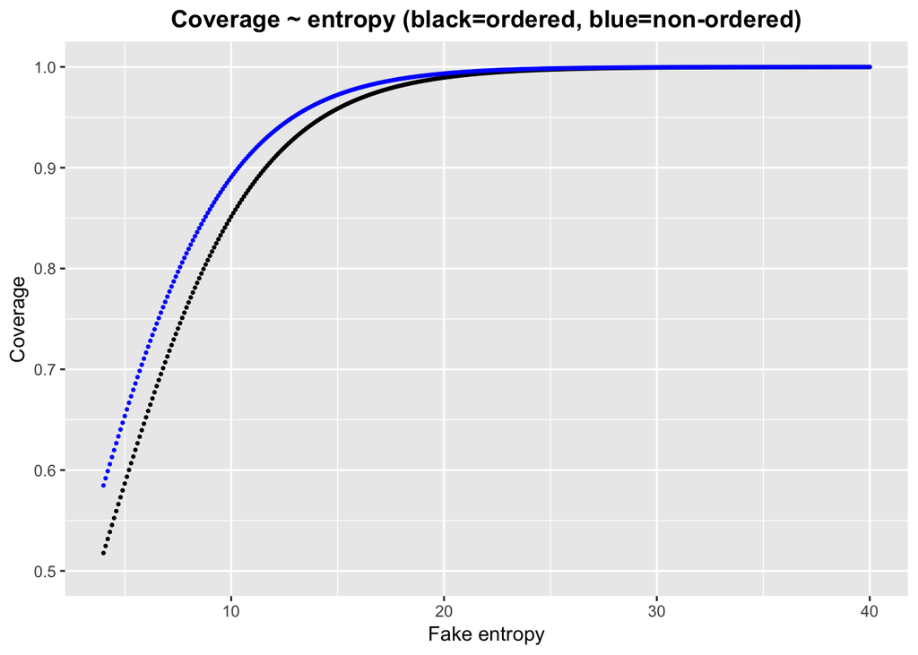

Both curves plateau as the entropy value reaches approximately 20. This value represents a high disorder system, whereby one snp takes a huge proportion of the posterior probability. On analysis of the ordered data, there were many (~8%) cases where $size=1$, $nvar=1$ and $covered=TRUE$, representing a system where one snp (the CV) has *all* the posterior probability. Conversely, in the non-ordered system, there were many instances of $size=1$, but few with $nvar=1$ (as this would only be the case when the first snp has all the posterior probability).

For any entropy value, the coverage for non-ordered sets is higher than that for ordered sets. This does **not** sound right as we know there are instances of over and undercoverage for different values of OR.

We know that entropy depends on OR, see below for seperate plots for each value of OR. Since they are all so different, seems silly to ‘squish’ them all into one plot. Idea: Could also include OR (and interaction term?) in the glm.

Ordered:

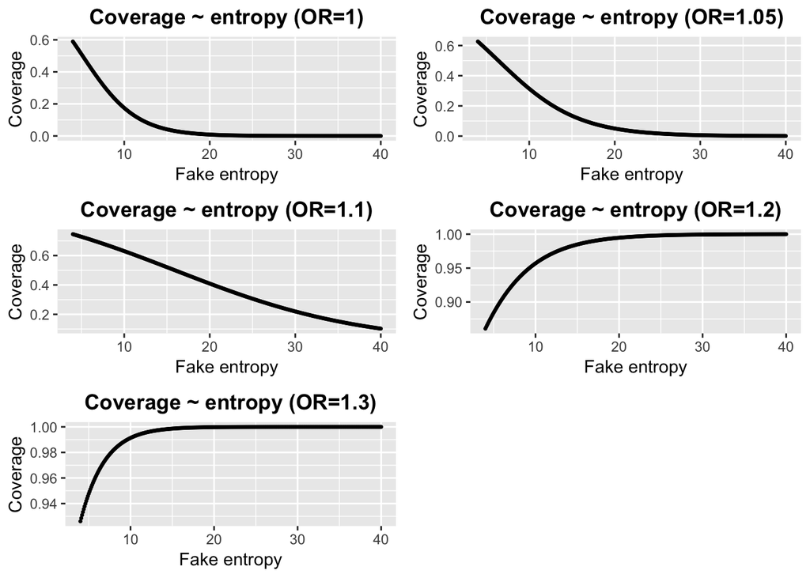

Non-ordered

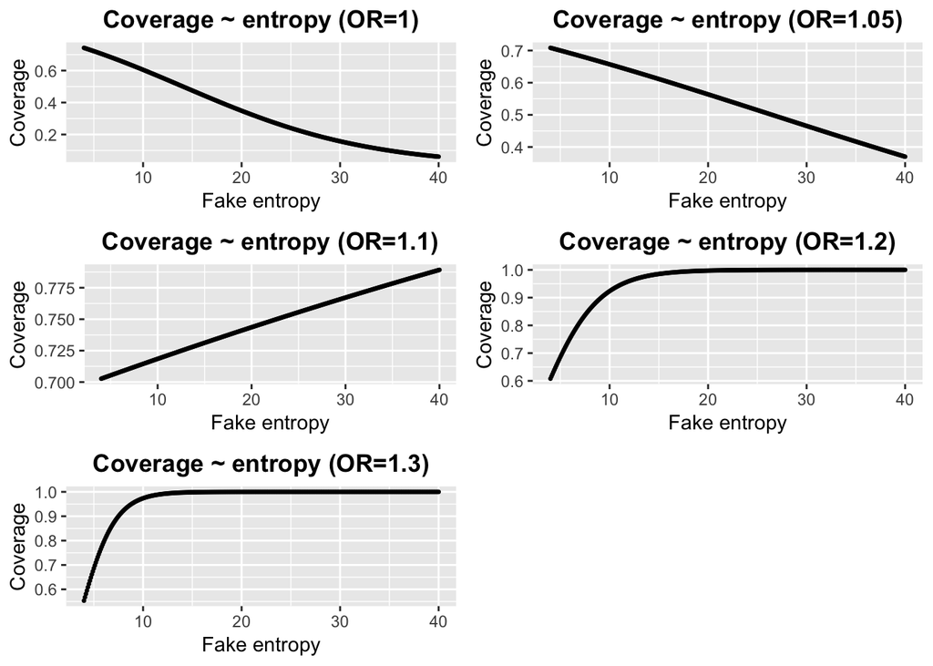

#### Threshold

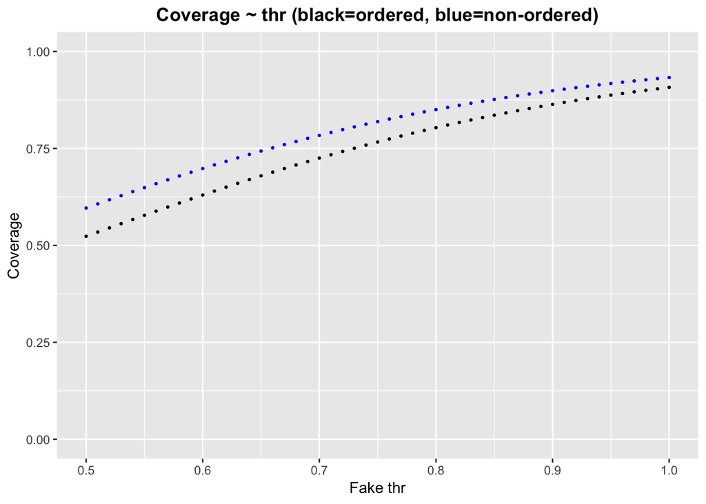

The graph shows that coverage is higher for any threshold value for non-ordered sets compared with ordered sets. As the threshold increases to 1, the difference between coverage for ordered and non-ordered sets decreases.

#### Size

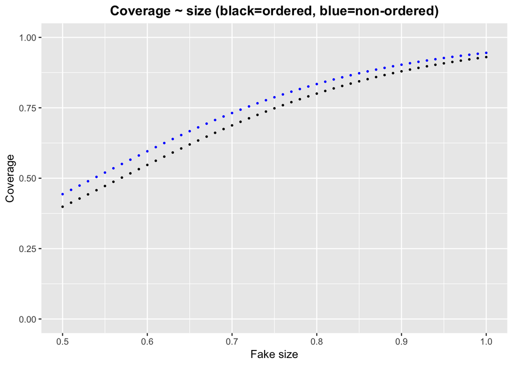

Similarly to coverage~thr (since size and thr are closely related), it seems that coverage is higher for any size value for non-ordered sets compared with ordered sets. As the size increases to 1, the difference between coverage for ordered and non-ordered sets decreases.

Note the difference in plots for thr and size for 0.5-0.8.

#### nsnps

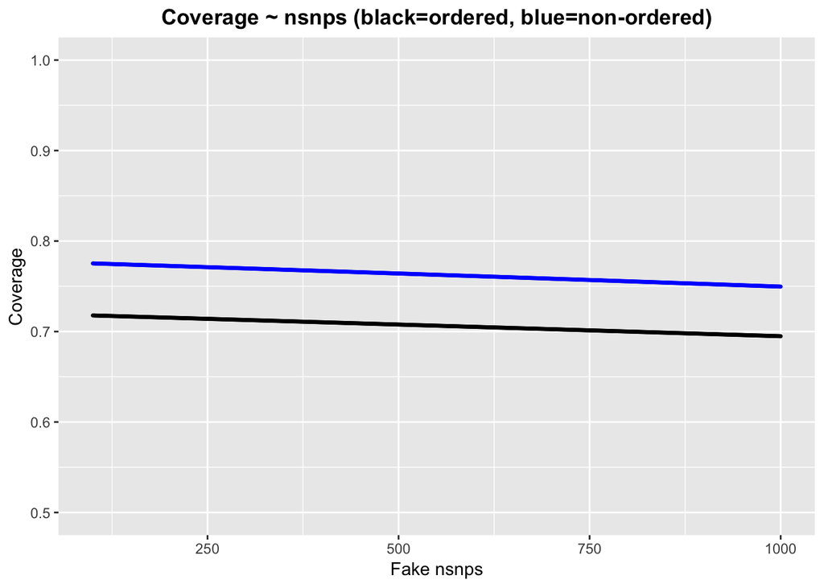

As the number of snps increases in the system, the coverage decreases slightly.

#### N

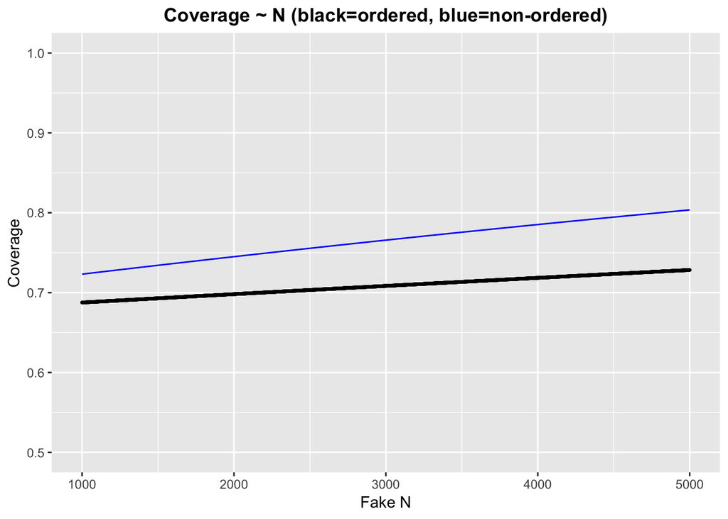

As N increases, coverage increases. This increase is faster for non-ordered as opposed to ordered sets.

This plot doesn’t make much sense.. perhaps something wrong with the code?

#### nvar

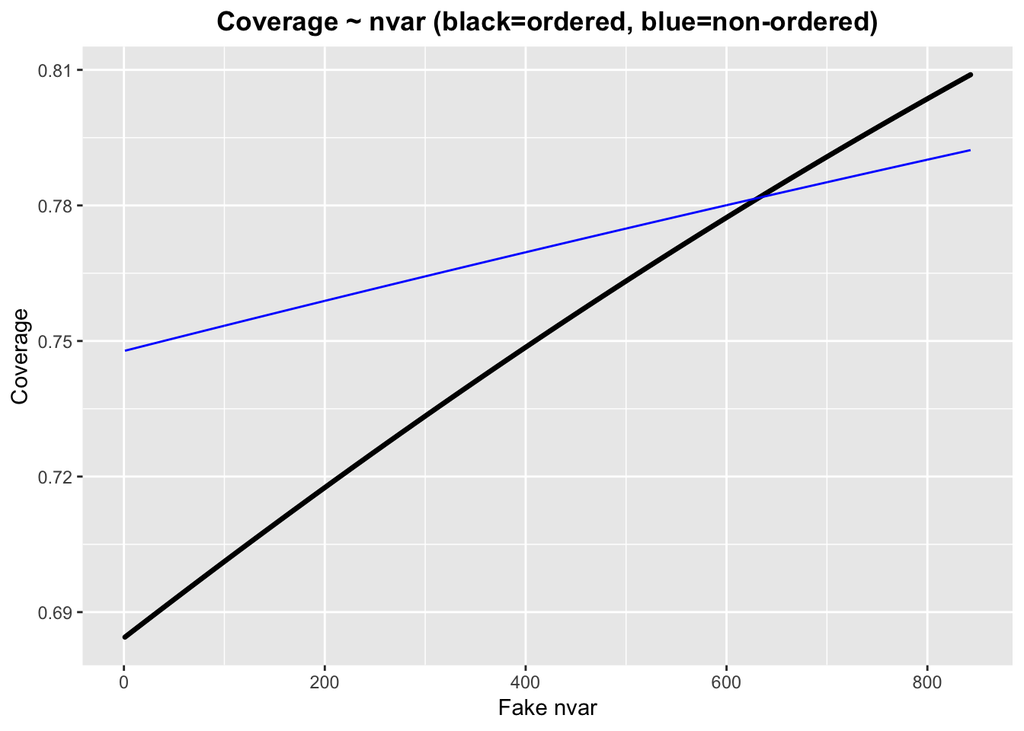

As nvar increases, coverage increases. This increase is steeper for ordered sets and coverage for ordered sets beats that for non-ordered sets at nvar approx 625.

#### OR

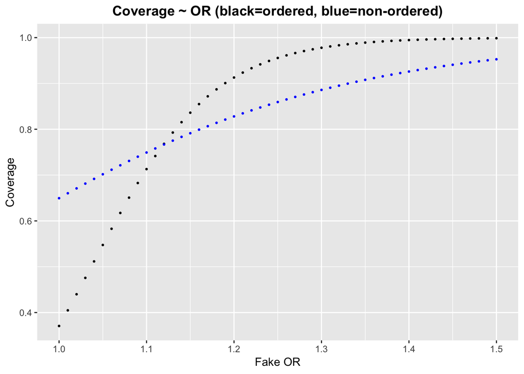

Coverage for ordered sets increases rapidly for OR=1-1.15 and plateaus at OR=1.4. For non-ordered sets, the increase in coverage is a lot slower. For OR=1 (the odds of disease for people with and without the allele is equal), coverage is a lot higher for non-ordered sets (~0.65) than ordered sets (~0.38), presumably because the CV would not hold a substantial proportion of the posterior probability, and therefore would not necessarily appear towards the beginning of the ordering.